# Coursework Report

*N* removed NAs: 2

*N* removed typo: 1

*N* removed <18: 28

*N* total clean: 119

| Group | *N* | *M*<sub>age</sub> | *M*<sub>rating</sub> |
| --- | --- | --- | --- |
| Control | 55 | 21.1 | 5.80 |
| Experim | 64 | 21.1 | 6.43 |

**Main analysis results**

*t*(117) = -4.26, *p* < .001

[interactive chart not shown]

[figure not shown]

[interactive chart not shown]

# Coursework Report

Analysing Data, Spring 2020

# Methods

## Participants

**Figure 1: A Table of Descriptive Statistics by Group**

| Group | *N* | % | µ <sub>Years</sub> | s <sub>Years</sub> | Min <sub>Years</sub> | Max <sub>Years</sub> | µQ1 | µQ2 | µQ3 | µ composite |
| --- | --- | --- | --- | --- | --- | --- | --- | --- | --- | --- |
| control | 55 | 46.2 | 21.1 | 2.0 | 18 | 25 | 5.82 | 5.73 | 5.85 | 5.80 |
| experimental | 64 | 53.8 | 21.1 | 2.4 | 18 | 29 | 6.30 | 6.58 | 6.41 | 6.43 |

## Design

This study was carried out to explore whether colour influences attractiveness which was investigated by participants reporting their judgment of the attractiveness of an individual on different coloured backgrounds (white and red), a replication of the first Elliot et al, 2010 study. Participants were informed that the experiment was to study first impressions of others, a picture of a moderately attractive man on either a red or white coloured background was presented to the participants for around 5 seconds before participants were asked to rate the attractiveness of the man on a 1-9 scale (Elliot et al,2010). The independent variable in this study is the condition in which participants were randomly assigned, the experimental group or the control group. The experimental group viewed the individual used in the experiment on a red background whereas the control group viewed the same individual on a white background, white was used for the control as it is a neutral colour. The individual in the picture presented to participants was a moderately attractive male (Elliot et al, 2010). Experimenters were not informed of the participants’ colour condition throughout the experiment. The dependant variable in this experiment is how attractive participants in the two conditions found the individual, attractiveness was measured on a 1-9 rating scale for 3 separate questions: ‘How attractive do you think this person is?’, ‘How pleasant is this person to look at?’, ‘If I were to meet the person in this picture face to face, I would think he is attractive’, a composite score was calculated for these 3 questions for each participant to gain an average rating of attractiveness with 1 being the least attractive and 9 being the highest rating of attractiveness. The hypothesis being tested is: participants viewing the individual on a white background will give significantly different ratings on attractiveness in comparison to participants viewing the same individual on a red background and this hypothesis will be tested through an independent *t* test calculation to measure the significance of the results obtained through the experiment.

# Results

In general, mean attractiveness ratings in the experimental condition were higher than those reported by the control condition; the composite score of attractiveness ratings was 5.8 for the control group and 6.43 for the experimental group, with a rating difference of 0.63 between the two groups. Results from our statistical analysis suggests that there was a significant difference in the mean attractiveness ratings of the experimental and control groups (Mean<sub>diff</sub> = 0.63, CI [-0.92, -0.34], *t*(117) = -4.26, p < 0.001). Our obtained difference in means for the two conditions (0.63) is -4.26 times larger than the standard error of the difference in means. This value is unlikely to occur if the true difference in means is 0 (p < 0.001), therefore, it is unlikely that the samples obtained are from the same population. The statistical analysis results suggest the null hypothesis may not be true (there is no significant difference between the group means) and that there is significant evidence to accept the alternative hypothesis of colour influencing attractiveness ratings.

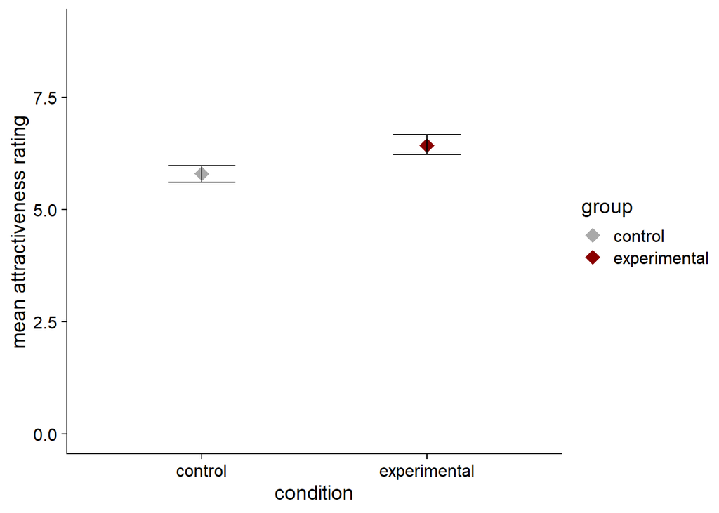

**Figure 2: A plot to show the mean attractiveness ratings for each condition, CI (-0.92, -0.34)**

# Discussion

Although the original Elliot (2010) study provided statistically significant results to suggest red does influence perceived attractiveness, the study was called into question for publication bias. Due to the small sample sizes of Elliot’s several studies into red and attraction, the power of his data was low and did not correctly correlate with the number of experiments that successfully disproved the null hypothesis and thus it can be assumed that some form of publication bias has taken place (Francis, 2013), deeming his results unreliable. In response to being accused of publication bias, Elliot carried out a replication of his original study (Elliot & Maier, 2013) with results (Mean<sub>diff</sub> = 0.36, *t*= 1.51, p = 0.13), finding a *t* value not significant enough to accept the difference in means being caused by colour manipulation and rather by chance.

On the contrary, there has also been an array of research support for the red effect on attractiveness in both men and women (Elliot & Maier, 2013). As a consequence of largely conflicting evidence, it is difficult to reach a clear conclusion of whether the red effect truly exists and influences perceived attractiveness without further research.

The research question of whether red influences attraction most definitely requires further research as there is currently an overwhelming amount of conflicting research, making it very difficult to come to a clear conclusion of the effect’s existence. Future research should aim to not only investigate the effect in viewing moderately attractive models but an array of models of varied attractiveness in order to increase ecological validity as it is unlikely that individuals are exposed to solely moderately attractive individuals in real-life situations. This can be achieved by experimenters including a larger number of models of varied attractiveness into the study as an additional independent variable. Also, studies should consist of large samples as this will increase the reliability and power of those studies, qualities that are rare in current studies in the research area.

To conclude, our study into the effect of red on attractiveness yielded statistically significant results suggesting that the colour red may increase the perceived attraction of a moderately attractive model, with participants in the experimental (red) condition giving a higher mean attractiveness rating to the model in comparison to those participants in the control (white) condition. The trend of individuals being perceived as of higher attractiveness in conjunction with the colour red is seen throughout the research area, but few studies’ results prove statistically significant, there are however some studies resulting in statistically significant results to show red being correlated with increased attraction ratings. Due to the magnitude of conflicting evidence, the research area requires more in depth research in order to reach a clearer conclusion of the effect of red on perceived attraction.

# References

Elliot, A. J., & Maier, M. A. (2013). The red-attractiveness effect, applying the ioannidis and trikalinos(2007b) test, and the broader scientific context: A reply to francis (2013). Journal of Experimental Psychology: General. https://doi.org/10.1037/a0029592

Elliot, A. J., Niesta Kayser, D., Greitemeyer, T., Lichtenfeld, S., Gramzow, R. H., Maier, M. A., & Liu, H. (2010). Red, Rank, and Romance in women viewing men. Journal of Experimental Psychology: General, 139(3), 399–417. https://doi.org/10.1037/a0019689

Francis, G. (2013). Comment publication bias in Red, Rank, and Romance in women viewing men, by Elliot et al. (2010). Journal of Experimental Psychology: General. https://doi.org/10.1037/a0027923

Hesslinger, V. M., Goldbach, L., & Carbon, C. C. (2015). Men in red: A reexamination of the red-attractiveness effect. Psychonomic Bulletin and Review. https://doi.org/10.3758/s13423-015-0866-8

Peperkoorn, L. S., Roberts, S. C., & Pollet, T. V. (2016). Revisiting the red effect on attractiveness and sexual receptivity: No effect of the color red on human mate preferences. Evolutionary Psychology, 14(4), 1–13. https://doi.org/10.1177/1474704916673841